# Challenge 1 - Energy Production Data Simulation

by Kazuki Minamiya

```python
#! /usr/bin/env python
# -*- coding:utf-8 -*-
import csv
import numpy as np
import statsmodels.tsa.stattools as st
import pandas as pd
import matplotlib.pyplot as plt
import statsmodels.tsa.vector_ar as var
import statsmodels.tsa.api
```

```python
data_train = pd.read_csv('../../data/training_dataset_500.csv')
data_test = pd.read_csv('../../data/test_dataset_500.csv')
data_set = pd.read_csv('../../data/dataset_500.csv')
data_train.head(5)
```

|  | ID | Label | House | Year | Month | Temperature | Daylight | EnergyProduction |
| --- | --- | --- | --- | --- | --- | --- | --- | --- |
| 0 | 0 | 0 | 1 | 2011 | 7 | 26.2 | 178.9 | 740 |
| 1 | 1 | 1 | 1 | 2011 | 8 | 25.8 | 169.7 | 731 |
| 2 | 2 | 2 | 1 | 2011 | 9 | 22.8 | 170.2 | 694 |
| 3 | 3 | 3 | 1 | 2011 | 10 | 16.4 | 169.1 | 688 |
| 4 | 4 | 4 | 1 | 2011 | 11 | 11.4 | 169.1 | 650 |

5 rows × 8 columns

```python
data_test.head(5)
```

|  | ID | Label | House | Year | Month | Temperature | Daylight | EnergyProduction |
| --- | --- | --- | --- | --- | --- | --- | --- | --- |
| 0 | 23 | 23 | 1 | 2013 | 6 | 22.0 | 125.5 | 778 |
| 1 | 47 | 23 | 2 | 2013 | 6 | 21.1 | 123.1 | 627 |
| 2 | 71 | 23 | 3 | 2013 | 6 | 21.9 | 126.8 | 735 |
| 3 | 95 | 23 | 4 | 2013 | 6 | 20.2 | 125.2 | 533 |
| 4 | 119 | 23 | 5 | 2013 | 6 | 20.2 | 125.2 | 533 |

5 rows × 8 columns

## 1. Decide an algorithm for this challenge

To decide a prime candidate for the algorithm solving this challenge, I go through the data-set and sort out the points of the results below:

- The data-set is a time series.
- However, it is only 23 months' worth of data.
- Unfortunately the number of unique data in the data-set is just 28 in spite of data-set obtained from 500 houses, and it means that many houses have exactly the same time series data. I think that the model made from such a data-set cannot be evaluated accurately.

For the reason listed above, I first decide to delete overlapped data to make unique data-set (23 months' data-set of 28 houses). In this case, the prediction model for the future of the process based on its present or previous state such as time series analysis and markov process are suited for such a data-set. In the case of time series analysis, a decrease of data-set doesn't matter much because the prediction model is basically built with only each previous data per house.

I understand the data-set, which cover just 23 months, may not be enough, but as a prime candidate for the algorithm attacking this challenge, I decide to build a prediction model with time series analysis.

```
The number of houses: 28
```

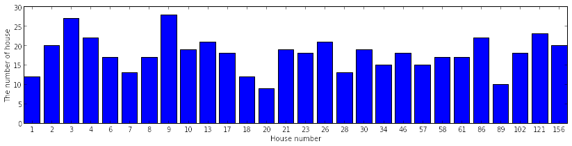

```python
data_per_house=[tuple([tuple(data_train[data_train.House==x][column]) for column in ['Temperature','Daylight','EnergyProduction']]) for x in range(1,501)]
data_uniq=[]; datai=[]
for j, i in enumerate(data_per_house):
    if not i in datai:
        datai.append(i)
        data_uniq.append(j+1)

data_uniq_len = len(set(data_per_house))
print "The number of houses: " + str(data_uniq_len)
plt.figure(figsize=(14,3))
plt.bar(np.arange(28), map(lambda x: data_per_house.count(x), set(data_per_house)), align='center')
plt.xticks(np.arange(data_uniq_len), data_uniq)
plt.xlabel('House number'); plt.ylabel('The number of house');
plt.autoscale(axis='x')
plt.show()
```

The above chart represents the number of houses per unique data.  
House numbers used for this challenge are below:  
(1, 2, 3, 4, 6, 7, 8, 9, 10, 13, 17, 18, 20, 21, 23, 26, 28, 30, 34, 46, 57, 58, 61, 86, 89, 102, 121, 156)

## 2. Format the data-set for Time Series Analysis

##### Through this challenge, "statsmodels" library is used for time series analysis. The docs is here http://statsmodels.sourceforge.net/

For time series analysis, it is very important that the time series data is stationary. To confirm the state, I plot "house 1" data as an example. Before plotting, I already confirmed each house has a similar wave shape.

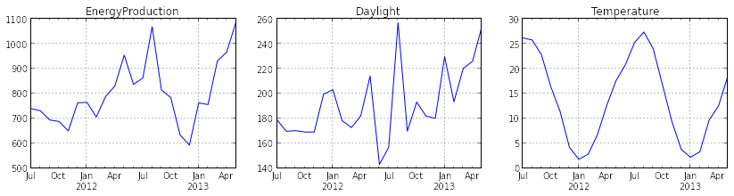

```python
rng=pd.date_range('7/1/2011', '6/1/2013', freq='M')
house1 = data_train[data_train.House==1][['EnergyProduction','Daylight','Temperature']].set_index(rng)
fig, axes = plt.subplots(nrows=1, ncols=3)
for i, column in enumerate(house1.columns):
    house1[column].plot(ax=axes[i], figsize=(14,3), title=column)
```

From the above charts, EnergyProduction and Daylight have trend components and week seasonal components, and also Temperature has very strong seasonal component. It means the data-set is not stationary. To remove the trend components, the first differences(1-Diff) of the three variables are taken and plotted.

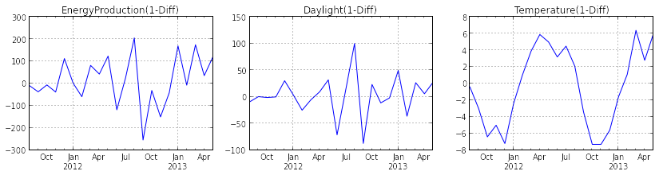

```python
fig, axes = plt.subplots(nrows=1, ncols=3)
for i, column in enumerate(house1.columns):
    house1[column].diff().dropna().plot(ax=axes[i], figsize=(14,3), title=column+'(1-Diff)')
plt.show()
```

From the above charts, trend components of EnergyProduction and Daylight is mostly removed. However, seasonal components of three variables, especially Temperature, are not removed yet. I attacked this problem, but the seasonal components could not be removed meaningfully because the data-set cover only 23 months, even if the period of the data-set is 12 months.  
Before making a model, I take a unit root test (Dickey-Fuller test) to confirm the trend components are really removed.

```python
print 'P-value of root unit test'
print 'EnergyProduction: ' + str(round(st.adfuller(house1.EnergyProduction.diff().dropna())[1],8))
print 'Daylight:         ' + str(round(st.adfuller(house1.Daylight.diff().dropna())[1],11))
print 'Temperature:      ' + str(round(st.adfuller(house1.Temperature.diff().dropna())[1],11))
```

```
P-value of root unit test
EnergyProduction: 9.49e-06
Daylight:         6.63e-09
Temperature:      3.4263e-07
```

From the test, the fact that trend components has been removed is confirmed all right.

## 3. Build and evaluate a prediction model

In this case, the model is built with Vector autoregression (VAR) per house.

```python
def mape_of_var(house, predfile, mapefile):
    sum0 = 0
    f_pred = open(predfile, 'w')
    f_mape = open(mapefile, 'w')
    pred_writer = csv.writer(f_pred)
    pred_writer.writerow(['House','EnergyProduction'])
    for i in house:
        data = data_train[data_train.House==i][['EnergyProduction','Daylight','Temperature']].set_index(rng)
        data_diff = data.diff().dropna()
        model = var.var_model.VAR(data_diff)
        results = model.fit(4, trend='nc')
        lag_order = results.k_ar
        data_pred = results.forecast(data_diff.values[-lag_order:],1)[0,0]+data.EnergyProduction[-1]
        sum0 = sum0 + abs(data_pred-data_test.EnergyProduction[i-1])/data_test.EnergyProduction[i-1]
        pred_writer.writerow([i,data_pred])

    mape = round(sum0/len(house),3)
    f_mape.write(str(mape))
    f_pred.close()
    f_mape.close()

    return mape

print 'MAPE(28 houses): ' + str(mape_of_var(data_uniq, 'pred_uniq.csv','mape_uniq.txt'))
print 'MAPE(500 houses): ' + str(mape_of_var(range(1,501), 'pred_all.csv','mape_all.txt'))
```

```
MAPE(28 houses): 0.098
MAPE(500 houses): 0.097
```

From the result, MAPE is 0.098.  
In the case of using 500 houses data-set, MAPE is 0.097. It means the model made from original data-set is overestimated by 0.1%. However, fourtunately (?) the duplication of data is not matter at all in this case...